# Figure 4b

5 year survival analysis

Jimmy Van den Eynden and Jason T. Serviss

31/01/2017

#### *Introduction*

Correlation analysis between the effects on the 5-year survival probability of TP53-mutated samples, low lncTAM34a expression, and low miR34a expression as indicated. For each variable the 5-year survival probability was compared to the control group (negative values indicate lower survival, positive values indicate higher survival). Spearman correlation coefficients are given on top left of each plot. Each dot indicates one cancer type. Boxplots on the bottom summarize the effects for the parameter on the x-axis, with indication of P values, as calculated using paired Wilcoxon signed rank test. Low expression was defined as TP53 non- mutated samples having expression values in the bottom 10th percentile.

#### *Methods*

RNAseq data was downloaded from TCGA and processed as described previously. Briefly, RNAseq data were aligned to the human hg19 assembly and quantified using GENCODE (v19) annotated HTSeq-counts and FPKM normalizations. Expression data from miR34a and lncTAM34a (identified as RP3-510D11.2) were used for further analysis.

#### *Results*

```r
data <- getData("Figure 4b")
correlation_matrix <- filter(data, !is.na(TP53) & !is.na(lncTAM34a))
cancers <- sort(unique(correlation_matrix$Cancer))

#TP53 status independant
#Set up all combinations of variables to calcualte survival probability for
independant <- expand.grid(
  gene = c("lncTAM34a", "miR34a", "TP53"),
  cancer = cancers,
  geneLevel = c("low", "others")
) %>%
  as_tibble() %>%
  arrange(cancer, gene, geneLevel) %>%
  mutate_if(is.factor, as.character) %>%
  group_by(gene, cancer, geneLevel) %>%
  #add data of the corresponding cancer
  mutate(data = map(cancer, function(c, cm = correlation_matrix) {
    filter(cm, Cancer == c)
  })) %>%
  #select the gene to be examined
  mutate(data = pmap(list(gene, data), function(g, d) {
      select(d, g, vitalStatus, FU)
  })) %>%
  #calculate the percentile for the gene's expression for each sample
  mutate(data = map2(gene, data, function(g, d) {
    if(any(grepl("TP53", colnames(d)))) {
      mutate(d, percentile = NA)
    } else {
      mutate(d, percentile = ntile(x = d[[1]], n = 10))
    }
  })) %>%
  #classify 10th percentile and under as "low" and the rest as "others"
  #classify TP53 mutated as low and WT as others
  mutate(data = map(data, function(d) {
    if(any(grepl("TP53", colnames(d)))) {
      mutate(d, class = if_else(TP53, "low", "others"))
    } else {
     mutate(d, class = if_else(percentile == 1, "low", "others"))
    }
  })) %>%
  #filter data class to correspond to expected geneLevel
  mutate(data = map2(geneLevel, data, function(gl, d) {
    filter(d, class == gl)
  })) %>%
  #calculate survival probability
  mutate(surv.obj = map(data, ~get_survival(.x))) %>%
  mutate(surv.fit = map(surv.obj, ~survival_fit(.x))) %>%
  mutate(surv.prob = map_dbl(surv.fit, ~calcSurvProb(.x))) %>%
  ungroup() %>%
  select(-data, -surv.fit) %>%
  mutate(type = "independant")


# TP53 status dependent
#Set up all combinations of variables to calcualte survival probability for
dependant <- expand.grid(
  gene = c("lncTAM34a", "miR34a"),
  mutation = c(TRUE, FALSE),
  cancer = cancers,
  geneLevel = c("low", "others")
) %>%
  as_tibble() %>%
  arrange(cancer, mutation, gene, geneLevel) %>%
  mutate_if(is.factor, as.character) %>%
  group_by(gene, mutation, cancer, geneLevel) %>%
  #add data of the corresponding cancer and TP53 status
  mutate(data = pmap(list(cancer, mutation), function(c, m, cm = correlation_matrix) {
    filter(cm, Cancer == c & TP53 == m)
  })) %>%
  #select the gene to be examined
  mutate(data = pmap(list(gene, data), function(g, d) {
      select(d, g, vitalStatus, FU)
  })) %>%
  #calculate the percentile for the gene's expression for each sample
  mutate(data = map2(gene, data, function(g, d) {
    mutate(d, percentile = ntile(x = d[[1]], n = 10))
  })) %>%
  #classify 10th percentile and under as "low" and the rest as "others"
  mutate(data = map(data, function(d) {
    mutate(d, class = if_else(percentile == 1, "low", "others"))
  })) %>%
  #filter data class to correspond to expected geneLevel
  mutate(data = map2(geneLevel, data, function(gl, d) {
    filter(d, class == gl)
  })) %>%
  #remove comparisons where there is not enough data
  mutate(bool = map_lgl(data, function(d) {
    !nrow(d) <= 1
  })) %>%
  filter(bool) %>%
  #calculate survival probability
  mutate(surv.obj = map(data, ~get_survival(.x))) %>%
  mutate(surv.fit = map(surv.obj, ~survival_fit(.x))) %>%
  mutate(surv.prob = map_dbl(surv.fit, ~calcSurvProb(.x))) %>%
  ungroup() %>%
  select(-(data:surv.fit)) %>%
  mutate(type = "dependent")

#combine the analyses and filter those to be included in the figure
survData <- bind_rows(dependant, independant) %>%
  filter(!is.na(surv.prob)) %>%
  filter((type == "dependent") | (type == "independant" & gene == "TP53")) %>%
  filter(is.na(mutation) | mutation == FALSE) %>%
  group_by(gene, mutation, cancer, type) %>%
  mutate(n = n()) %>%
  filter(n == 2) %>%
  summarize(relSurv = surv.prob[geneLevel == "low"] - surv.prob[geneLevel == "others"]) %>%
  ungroup() %>%
  select(-mutation, -type) %>%
  spread(gene, relSurv)
```

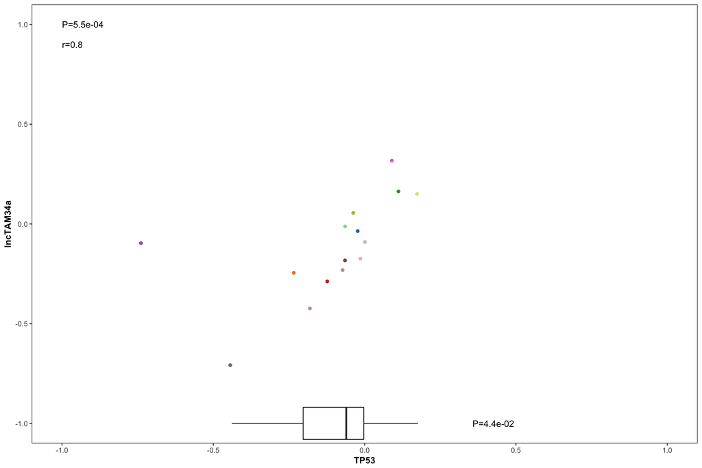

```r
#Add the colors for the plot to the data
colors <- getCancerColors()
survData <- full_join(survData, colors, by = "cancer")

#add ggplot theme
theme_remove_all <- theme_remove_all()

#plot 1
p1 <- mainPlot(survData, "TP53", "lncTAM34a", tRA = theme_remove_all)
p2 <- hPlot(survData, "TP53", tRA = theme_remove_all)
renderPlots(p1, p2)
```

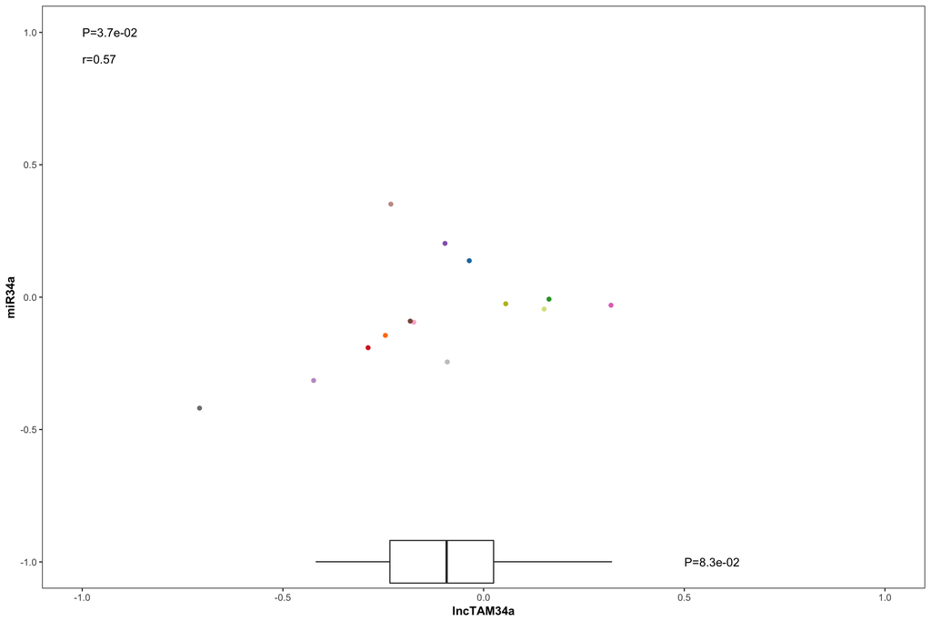

```r
#plot 2
p1 <- mainPlot(survData, "lncTAM34a", "miR34a", tRA = theme_remove_all)
p2 <- hPlot(survData, "lncTAM34a", tRA = theme_remove_all)
renderPlots(p1, p2)
```

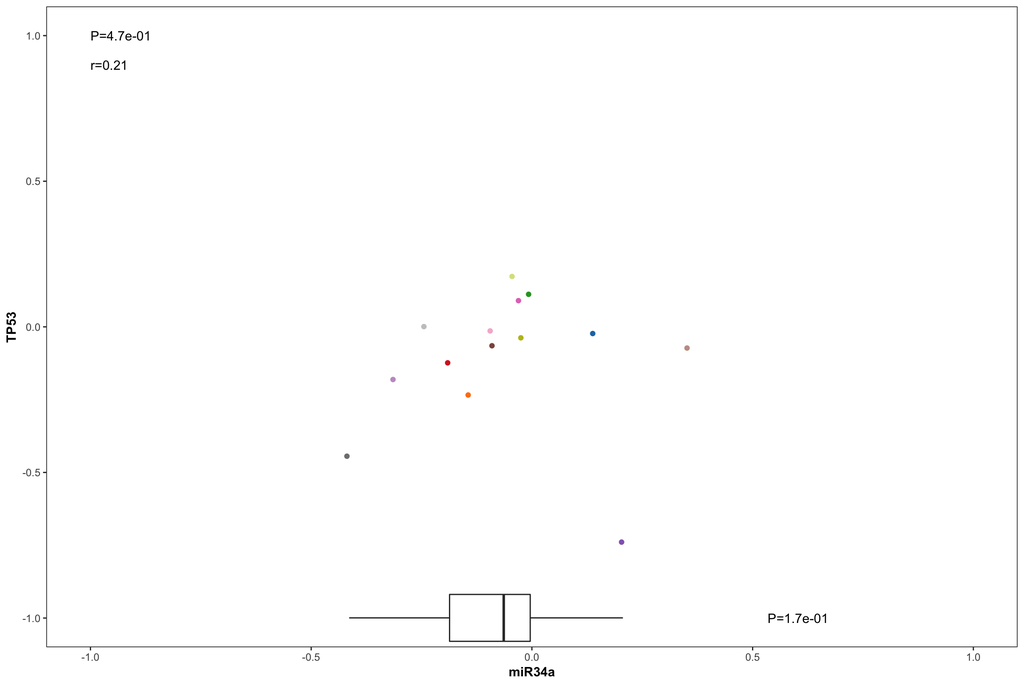

```r
#plot 3
p1 <- mainPlot(survData, "miR34a", "TP53", tRA = theme_remove_all)
p2 <- hPlot(survData, "miR34a", tRA = theme_remove_all)
renderPlots(p1, p2)
```